# Module 4 Pair Quiz

John Kyle C. Lluz, Adrian Enrico D. Rodriguez

7/30/2021

# Pair Quiz

## Question 1

### *An article in the Journal of Sound and Vibration [“Measurement of Noise-Evoked Blood Pressure by Means of Averaging Method: Relation between Blood Pressure Rise and PSL” (1991, Vol. 151(3), pp. 383-394)] described a study investigating the relationship between noise exposure and hypertension. The following data are representative of those reported in the article.*

| y | 1 | 0 | 1 | 2 | 5 | 1 | 4 | 6 | 2 | 3 | 5 | 4 | 6 | 8 | 4 | 5 | 7 | 9 | 7 | 6 |
| --- | --- | --- | --- | --- | --- | --- | --- | --- | --- | --- | --- | --- | --- | --- | --- | --- | --- | --- | --- | --- |
| x | 60 | 63 | 65 | 70 | 70 | 70 | 80 | 90 | 80 | 80 | 85 | 89 | 90 | 90 | 90 | 90 | 94 | 100 | 100 | 100 |

#### **A. Draw a scatter diagram of y (blood pressure rise in millimeters of mercury) versus x (sound pressure level in decibels). Does a simple linear regression model seem reasonable in this situation?**

```r
  y <- c(1, 0,  1,  2,  5,  1,  4,  6,  2,  3,  5,  4,  6,  8,  4,  5,  7,  9,  7,  6)
  x <- c(60,    63, 65, 70, 70, 70, 80, 90, 80, 80, 85, 89, 90, 90, 90, 90, 94, 100, 100, 100)

  plot(x, y, pch = 16, cex = 1, col = "blue", main = "Relation between Blood Pressure Rise and PSL", xlab = "Sound Pressure Level (dB)", ylab = "Blood Pressure Rise (mmHg)")
  lm(y ~ x)
```

```
##
## Call:
## lm(formula = y ~ x)
##
## Coefficients:
## (Intercept)            x
##    -10.1315       0.1743
```

```r
  abline(lm(y ~ x))
```

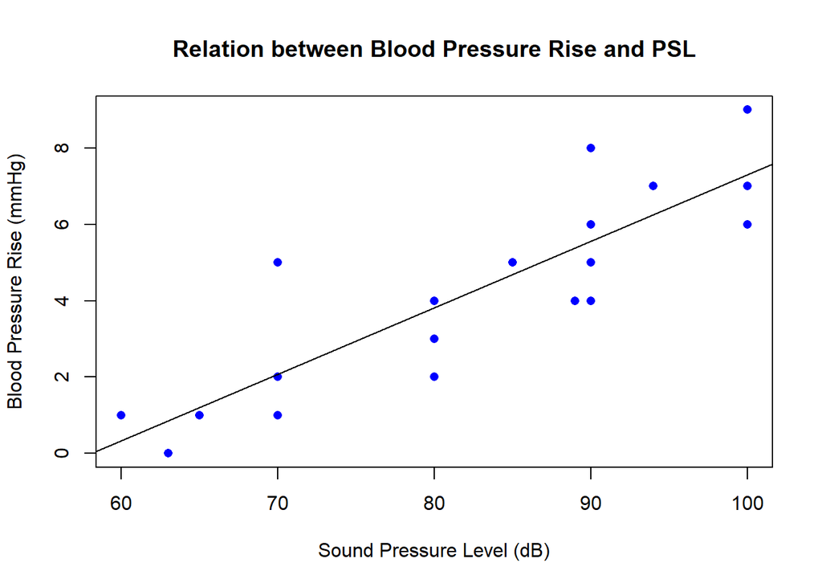

**Table A.1** *Scatter Diagram of x and y*

As seen in the scatter plot diagram in *Table A.1*, it is **reasonable to use a simple linear regression model** as there is a clear linear relationship present between variable x (sound pressure level) and y (blood pressure). For specificity, there is a direct relationship between both variables as when sound pressure level increases, so does the blood pressure.

#### **B. Fit the simple linear regression model using least squares. Find an estimate of $\sigma^2$**

##### For Simple Linear Regression Model:

Given the set of x and y values, we can determine the simple linear regression model using the **least squares method.** This method is best represented by the equation:

$\hat{y}=\hat{\beta_0}+\hat{\beta_1}x$  
*wherein:*  
$\hat{y}$ is the rise of blood pressure measured in mmHG  
$x$ is the sound pressure in dB  
$\beta_{0}$ and $\beta_1$ are the estimates for regression coefficients

It is worth taking note that this is **reminiscent of the slope intercept form** $y=mx+b$.

With that, we would have to solve for the following values and summations at $n=20$:

$$\sum_{i = 1}^{20} x_i = 1,656$$
$$\bar{x}=82.8$$
$$\sum_{i = 1}^{20} y_i = 86$$
$$\bar{y}=4.3$$
$$\sum_{i = 1}^{20} x_i^2 = 140,176$$
$$\sum_{i = 1}^{20} y_i^2 = 494$$
$$\sum_{i = 1}^{20} x_i y_1 = 7,654$$
With these values solved for already, we may proceed to solving for $S_xy$ and $S_xx$ as follows:

**For $S_xx$**
$$S_{xx} = \sum_{i = 1}^{n} x_i^2 - \frac{(\sum_{i = 1}^{n} x_i)^2}{n}$$
**For $S_xy$**
$$S_{xy} = \sum_{i = 1}^{n} x_i y_i - \frac{(\sum_{i = 1}^{n} x_i)(\sum_{i = 1}^{n} y_i)}{n}$$
We then plug in the values we have already solved for as follows:
**For $S_xx$**

$$S_{xx} = \sum_{i = 1}^{n} x_i^2 - \frac{(\sum_{i = 1}^{n} x_i)^2}{n}$$
$$S_{xx} = 140,176 - \frac{(1,656)^2}{20}$$
$S_{xx} = 3,059$

**For $S_xy$**

$$S_{xy} = \sum_{i = 1}^{n} x_i y_i - \frac{(\sum_{i = 1}^{n} x_i)(\sum_{i = 1}^{n} y_i)}{n}$$
$$S_{xy} = 7,654 - \frac{(1,656)(86)}{20}$$
$$S_{xy} = 533.2$$

Now that both have been solved for, we can now **calculate the estimates for regression coefficients as follows:**

**For $\hat{\beta_1}$**
$$\hat{\beta_1}= \frac{S_xy}{S_xx}$$
$$\hat{\beta_1}= \frac{533.2}{3,059.2}$$
$$\hat{\beta_1}= 0.1742939$$
**For $\hat{\beta_0}$**
$$\hat{\beta_0}=\overline{y}-\hat{\beta_1} \overline{x}$$
$$\hat{\beta_0}=4.3 - (0.1742939)(82.8)$$
$$\hat{\beta_0}=-10.1315349$$
This leaves with the equation for the best fit line or **the fitted simple linear regression model:**

$\hat{y}=0.1742939331x-10.13153766$

##### For estimating $\sigma^2$:

We will use the formula:
$$\sigma^2 = \frac{SS_E}{n-2}$$

$SS_E$ can be solved through R as follows:

```r
SSE <- lm(y~x)

sum(resid(SSE)^2)
```

```
## [1] 31.26647
```

Since we already have the value of $SS_E$, we can proceed with attaining $\sigma^2$ by plugging it into the equation former equation:

$$\sigma^2 = \frac{31.26647}{20-2}$$

$$\sigma^2 = 1.737026111$$

With that, we can conclude that **the estimated variance is $\sigma^2=1.737026111$**

#### **C. Find the predicted mean rise in blood pressure level associated with a sound pressure level of 85 decibels.**

Given the fitted simple line regression model, we can further obtain other useful data such **predicting the mean rise in blood pressure given a particular pressure level**. If we try to predict blood pressure level mean rise at 85 dB, we get the following solution:

$\hat{y}=0.1742939331x-10.13153766$  
$\hat{y}=0.1742939331(85)-10.13153766$  
$\hat{y}=4.683446654$

The answer we solved for is 4.683446654 or approximately 5. With that, we can conclude by saying that the **estimated mean rise in blood pressure level at sound pressure level of 85 dB is 5mmHg**.

## Question 2

### **An article in Optical Engineering [“Operating Curve Extraction of a Correlator’s Filter” (2004, Vol. 43, pp. 2775-2779)] reported on the use of an optical correlator to perform an experiment by varying brightness and contrast. The resulting modulation is characterized by the useful range of gray levels. The data follow:**

| Brightness | Contrast | Useful Range |
| --- | --- | --- |
| 54 | 56 | 96 |
| 61 | 80 | 50 |
| 65 | 70 | 50 |
| 100 | 50 | 112 |
| 100 | 65 | 96 |
| 100 | 80 | 80 |
| 50 | 25 | 155 |
| 57 | 35 | 144 |
| 54 | 26 | 255 |

\

#### **A. Fit a multiple linear regression model to these data.**

```
##
## Call:
## lm(formula = usefulrange ~ brightness + contrast)
##
## Residuals:
##     Min      1Q  Median      3Q     Max
## -32.334 -20.090  -8.451   8.413  69.047
##
## Coefficients:
##             Estimate Std. Error t value Pr(>|t|)
## (Intercept) 238.5569    45.2285   5.274  0.00188 **
## brightness    0.3339     0.6763   0.494  0.63904
## contrast     -2.7167     0.6887  -3.945  0.00759 **
## ---
## Signif. codes:  0 '***' 0.001 '**' 0.01 '*' 0.05 '.' 0.1 ' ' 1
##
## Residual standard error: 36.35 on 6 degrees of freedom
## Multiple R-squared:  0.7557, Adjusted R-squared:  0.6742
## F-statistic: 9.278 on 2 and 6 DF,  p-value: 0.01459
```

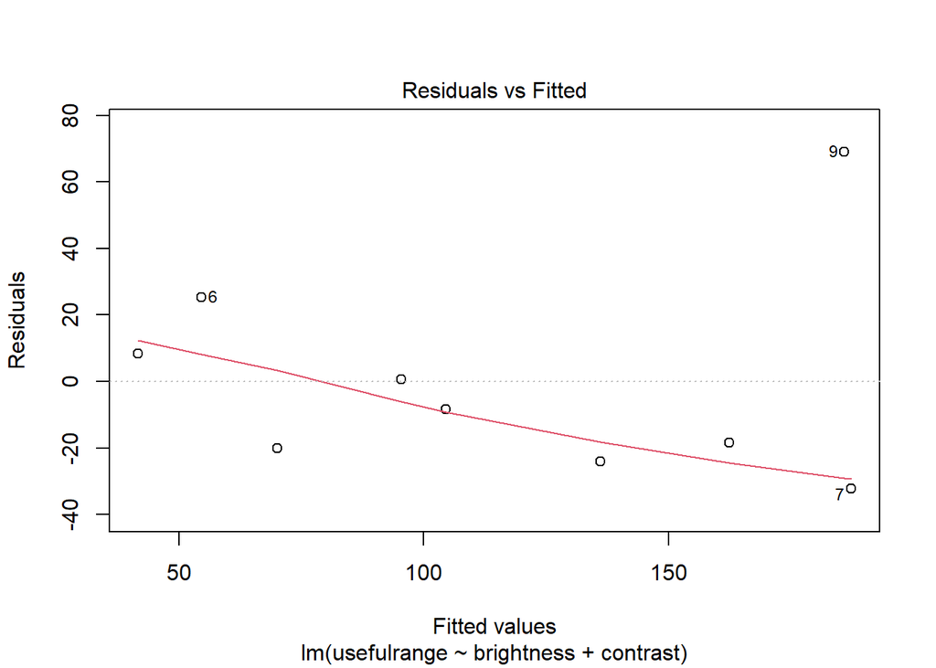

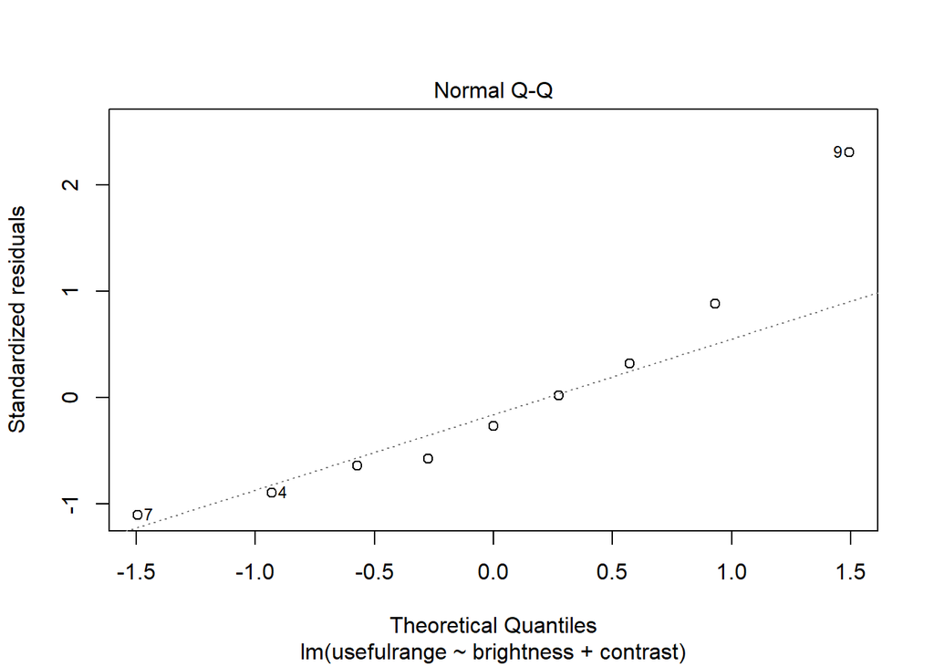

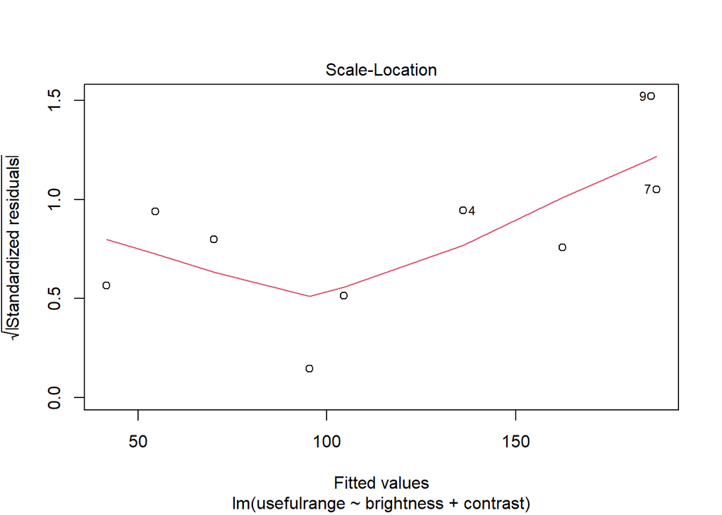

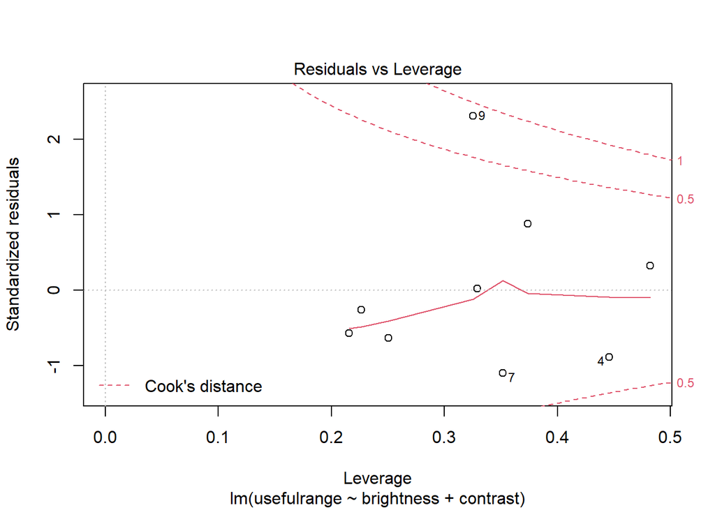

\

#### **B. Estimate $𝜎^2$.**

*Using R Function:*

```r
(summary(data2)$sigma)**2
```

```
## [1] 1321.273
```

**Solving For the *estimate of variance*.**

$$\sigma^2 = \frac{SS_E}{n-p}$$

$$\sigma^2 = \frac{7928}{9-3}$$

$$\sigma^2 = 1321.333$$

$$1321.273 \approx 1321.333 \approx 1321$$

\

#### **C. Compute the standard errors of the regression coefficients.**

**Using R function:**

|  | x |
| --- | --- |
| (Intercept) | 45.2284742 |
| brightness | 0.6762945 |
| contrast | 0.6887346 |

\

#### **D. Predict the useful range when brightness = 80 and contrast = 75.**

**Using R function:**

```r
newdata = data.frame(brightness=80,contrast=75)
predict(data2,newdata)
```

```
##        1
## 61.51477
```

**The Prediction is $\approx 61.5$ for the Useful Range, given that brightness is $80$% and contrast is $75$%**

\

#### **E. Test for significance of regression using 𝛼=0.05. What is the P-value for this test?**

```
##
## Call:
## lm(formula = usefulrange ~ brightness + contrast)
##
## Residuals:
##     Min      1Q  Median      3Q     Max
## -32.334 -20.090  -8.451   8.413  69.047
##
## Coefficients:
##             Estimate Std. Error t value Pr(>|t|)
## (Intercept) 238.5569    45.2285   5.274  0.00188 **
## brightness    0.3339     0.6763   0.494  0.63904
## contrast     -2.7167     0.6887  -3.945  0.00759 **
## ---
## Signif. codes:  0 '***' 0.001 '**' 0.01 '*' 0.05 '.' 0.1 ' ' 1
##
## Residual standard error: 36.35 on 6 degrees of freedom
## Multiple R-squared:  0.7557, Adjusted R-squared:  0.6742
## F-statistic: 9.278 on 2 and 6 DF,  p-value: 0.01459
```

$$H_0 : \sigma_1^2 = \sigma_2^2$$
$$H_1: \sigma_1^2 ≠ \sigma_2^2$$
$$The\ \ P-Value\ \ is\ \ 0.01459$$

$$P-Value\ \ <\ \ \alpha$$

$$\therefore \ Null\ \ Hypothesis\ \ is\ \ Rejected.$$

\

#### **F. Construct a t-test on each regression coefficient. What conclusions can you draw about the variables in this model? Use 𝛼=0.05.**

Mean of Brightness

| = |
| --- |
| 71.22222 |

```
##
##  One Sample t-test
##
## data:  bur
## t = 1.8174, df = 17, p-value = 0.08682
## alternative hypothesis: true mean is not equal to 71.22
## 95 percent confidence interval:
##   67.67102 118.88454
## sample estimates:
## mean of x
##  93.27778
```

$$H_0 : \beta_1 = \beta_{1,0}$$
$$H_0 : \beta_1 ≠ \beta_{1,0}$$

$$0.08682 > (\alpha=0.05)$$
**Failed to Reject.**

**$\therefore$ there is no linear relationship existing between Brightness and Useful Range.**

Mean of Contrast

| = |
| --- |
| 54.11111 |

[output not shown]

**References**

D. C. Montgomery and G. C. Runger, Applied statistics and probability for engineers. New York: Wiley, 2003.